# Spatial Correction of Field Trial Data

Step-by-step guide to `spatial_correct_gam.R`

14 March 2026

# 1 Background: the spatial correction problem

## 1.1 What is spatial variation?

Greenhouse and field trials rarely provide a perfectly uniform growing environment. Temperature gradients, irrigation patterns, differential light exposure, bench-edge drying, and soil heterogeneity all create structured variation in the measured phenotype that has nothing to do with the genotypes being evaluated. This environmental signal is called **spatial variation**.

A typical example: pots placed near a greenhouse wall receive less light and experience cooler night temperatures than pots in the centre of the bench. As a result, plants near the wall yield less, not because they are genetically inferior, but because their microenvironment was unfavourable.

## 1.2 Why does it matter?

When genotypes are assigned to positions at random (as they should be), spatial variation becomes **confounded noise**: a genotype that happened to be placed in a high-performing zone will appear falsely superior, while one placed in a low-performing zone will appear falsely inferior. The bias in the estimated genotype means (the raw treatment means) can easily exceed the true genetic differences we are trying to detect.

The goal of spatial correction is to **separate the genetic signal from the environmental noise**, recovering genotype estimates that are free of the spatial trend. The corrected values are called **BLUEs** (Best Linear Unbiased Estimators) when genotype is modelled as a fixed effect.

## 1.3 How `spatial_correct_gam.R` works

The script fits a **Generalised Additive Mixed Model** (GAMM) using the `mgcv` package. The spatial surface is captured by a two-dimensional P-spline tensor product smooth (`te(Row, Col, bs='ps')`), supplemented by row and column random effects (`s(row_f, bs='re')`) that absorb any remaining directional trends. Genotype is included as a fixed effect with no intercept, so each coefficient is directly the BLUE for that genotype on the phenotype scale.

**Single bench:** one GAM per bench, one spatial surface per bench.

**Multi-bench (this guide):** a single joint GAM fitted across all benches simultaneously, with a separate spatial surface per bench (`te(..., by = bench_f)`) and bench as an additional fixed effect. Fitting all benches jointly borrows strength across benches when estimating genotype effects.

# 2 Prerequisites

The workflow uses two scripts from this project. Source them before running any analysis.

```r
# Load simulation functions
source("../scripts/simulate_spatial_data.R")

# Load spatial correction functions
source("../scripts/spatial_correct_gam.R")
```

Functions now available:

| Script | Functions loaded |
| --- | --- |
| `simulate_spatial_data.R` | `simulate_field_trial()`, `plot_bench_heatmap()`, `plot_all_bench_heatmaps()` |
| `spatial_correct_gam.R` | `run_spatial_gam()`, `adaptive_nseg()`, `read_input()`, `empirical_semivariogram()`, `plot_heatmap()`, `plot_variogram()`, `make_diagnostic_plots()`, `fit_mgcv_bench()`, `fit_mgcv_joint()` |

# 3 Step 1: Simulate a trial dataset

## 3.1 The experimental design

We simulate a multi-bench greenhouse trial with the following structure:

- **4 benches** (Bench1-Bench4)
- **6 rows x 15 columns** per bench -> **90 genotypes**
- Each genotype appears **once per bench** (unreplicated within each bench, but with one observation per bench across 4 benches)
- **Edge-effect spatial pattern** (type 6): values elevated at bench borders with a diagonal asymmetry, mimicking common glasshouse conditions
- Spatial severity **increases** across benches (intensities 15 -> 60) to show how the model handles both mild and severe spatial gradients

The data-generating model is:

$$y_{ij} = g_i + s_j +
\varepsilon_{ij}$$

where $g_i \sim N(55,\ 12^2)$ is the true genotype effect, $s_j$ is the spatial deviation at plot $j$ (zero-centred per bench), and $\varepsilon_{ij} \sim N(0,\ 4^2)$ is random plot noise.

## 3.2 Running the simulation

```r
sim <- simulate_field_trial(
  n_bench                     = 4,
  n_rows                      = 6,
  n_cols                      = 15,
  mean_pheno                  = 55,
  sd_geno                     = 12,
  spatial_type                = 6,          # edge effects
  spatial_intensity           = 30,
  spatial_type_per_bench      = rep(6, 4),
  spatial_intensity_per_bench = c(15, 25, 40, 60),
  spatial_scale               = 1,
  sd_error                    = 4,
  pheno_min                   = 0,
  pheno_max                   = 100,
  pheno_name                  = "BNI",
  save_csv                    = TRUE,
  output_dir                  = "data",     # saved to docs/data/
  seed                        = 42
)
```

```
## Data written to:          data/BNI_simulation.csv
## True effects written to:  data/BNI_true_effects.csv
```

```r
dfr          <- sim$data
true_effects <- sim$true_effects
pheno        <- sim$pheno_name

cat("Rows:", nrow(dfr), "\n")
```

```
## Rows: 360
```

```r
cat("Genotypes:", length(unique(dfr$Genotype)), "\n")
```

```
## Genotypes: 90
```

```r
cat("Benches:", paste(sort(unique(dfr$Bench)), collapse = ", "), "\n")
```

```
## Benches: Bench1, Bench2, Bench3, Bench4
```

The `simulate_field_trial()` call writes two files to `docs/data/`:

- **`BNI_simulation.csv`**: the plot-level dataset you would pass to `run_spatial_gam()` (columns: `Bench`, `Genotype`, `Row`, `Col`, `True_Spatial`, `BNI`)
- **`BNI_true_effects.csv`**: the underlying genotype effects (columns: `Genotype`, `True_BNI`); used here to validate the correction but not available in a real experiment

## 3.3 The raw observed data

```r
benches <- sort(unique(dfr$Bench))

p_raw <- plot_all_bench_heatmaps(
  dfr          = dfr,
  pheno        = pheno,
  bench_col    = "Bench",
  shared_scale = TRUE,
  output_png   = "figures/guide_raw_observed.png",
  ncol_panels  = 2
)
```

```
## Heatmap saved to: figures/guide_raw_observed.png
```

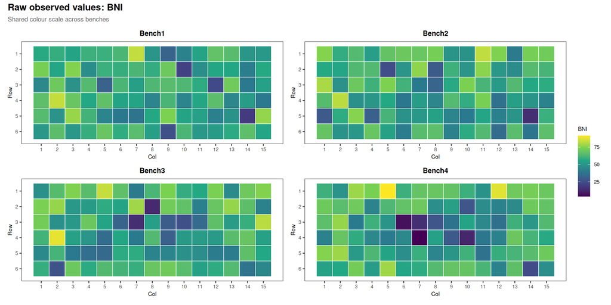

Raw observed BNI values across all four benches. Note how the colour pattern differs from bench to bench despite genotypes being randomly assigned. This is the spatial signal we need to remove.

```r
p_raw
```

# 4 Step 2: Understand the problem

## 4.1 The hidden spatial pattern

In a real experiment we cannot observe the spatial pattern directly; we only see the phenotype, which confounds genetics and environment. Here, because we simulated the data, we can look at the true spatial contribution at each plot.

```r
p_sp <- plot_all_bench_heatmaps(
  dfr          = dfr,
  pheno        = "True_Spatial",
  bench_col    = "Bench",
  shared_scale = TRUE,
  output_png   = "figures/guide_true_spatial.png",
  ncol_panels  = 2
) + plot_annotation(
  title    = "True spatial contributions",
  subtitle = "Edge-effect pattern (type 6). Values are zero-centred per bench.",
  theme    = theme(plot.title    = element_text(size = 13, face = "bold"),
                   plot.subtitle = element_text(size = 9, colour = "grey40"))
)
```

```
## Heatmap saved to: figures/guide_true_spatial.png
```

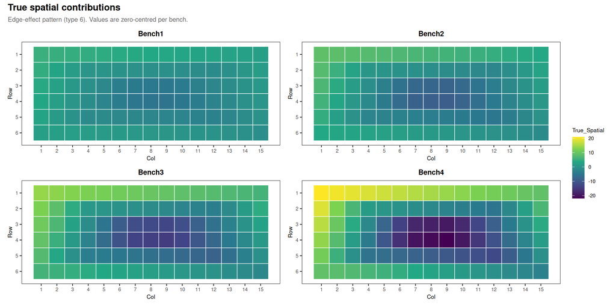

True spatial contributions used during simulation. The edge-effect pattern is clear: border plots are elevated, interior plots are depressed. The diagonal asymmetry (top-left high, bottom-right low) is also visible. Intensity increases from Bench1 to Bench4.

```r
p_sp
```

## 4.2 How spatial variation biases estimates

Without spatial correction, the standard approach is to use the raw mean phenotype per genotype. Because genotypes were placed randomly on the bench, a genotype that happened to land in a high-spatial zone will have an inflated mean; one in a low-spatial zone will be deflated.

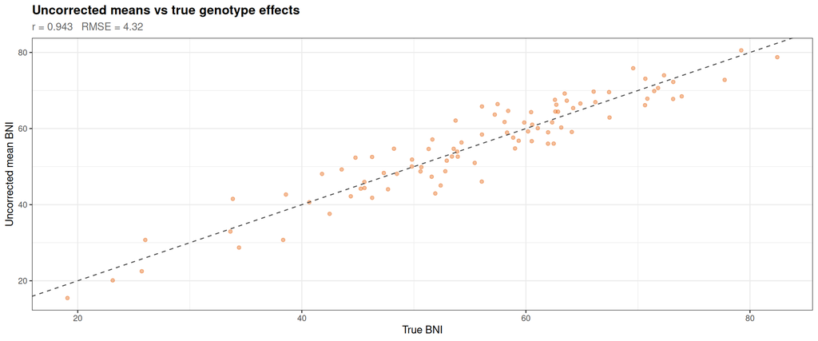

Uncorrected genotype means (averaged across benches) versus true genotype effects. The scatter around the 1:1 line reveals the bias introduced by spatial variation. The RMSE and correlation quantify how well raw means recover the truth.

```r
unc <- aggregate(dfr[[pheno]], list(Genotype = dfr$Genotype), mean)
colnames(unc)[2] <- "Mean"
unc_m <- merge(unc, true_effects, by = "Genotype")

r_unc    <- round(cor(unc_m$Mean,  unc_m$True_BNI), 4)
rmse_unc <- round(sqrt(mean((unc_m$Mean - unc_m$True_BNI)^2)), 2)

ggplot(unc_m, aes(x = True_BNI, y = Mean)) +
  geom_point(alpha = 0.4, size = 1.5, colour = "#e55c00") +
  geom_abline(slope = 1, intercept = 0, colour = "grey30",
              linetype = "dashed", linewidth = 0.5) +
  labs(
    title    = "Uncorrected means vs true genotype effects",
    subtitle = paste0("r = ", r_unc, "   RMSE = ", rmse_unc),
    x        = "True BNI",
    y        = "Uncorrected mean BNI"
  ) +
  theme_bw(base_size = 11) +
  theme(plot.title    = element_text(face = "bold"),
        plot.subtitle = element_text(colour = "grey40"))
```

```r
cat(sprintf("Uncorrected means:  r = %.4f,  RMSE = %.2f\n", r_unc, rmse_unc))
```

```
## Uncorrected means:  r = 0.9430,  RMSE = 4.32
```

The RMSE and correlation will improve substantially after spatial correction.

# 5 Step 3: Run `run_spatial_gam()`

## 5.1 Function arguments

`run_spatial_gam()` accepts all configuration as function arguments, so there is no configuration block to edit. Pass your data path and column names directly.

```r
run_spatial_gam(
  data_file,
  pheno_cols,
  output_dir    = "output/gam",
  geno_col      = "geno",
  row_col       = "row",
  col_col       = "col",
  bench_col     = NULL,
  estimate_type = "BLUEs",
  k_row         = NULL,
  k_col         = NULL,
  rda_object    = NULL
)
```

Key argument decisions:

| Argument | Default | Notes |
| --- | --- | --- |
| `data_file` | (required) | Path to a `.csv`, `.rda`, or `.RData` file |
| `pheno_cols` | (required) | One or more trait column names, e.g. `c("yield", "height")` |
| `output_dir` | `"output/gam"` | Directory for all outputs; created automatically if absent |
| `geno_col` | `"geno"` | Genotype identifier column |
| `row_col` / `col_col` | `"row"` / `"col"` | Numeric row/column coordinates; no NAs allowed |
| `bench_col` | `NULL` | Bench/trial identifier. `NULL` triggers single-bench model; a column name triggers the joint multi-bench model |
| `estimate_type` | `"BLUEs"` | `"BLUEs"` (genotype fixed, no shrinkage), `"BLUPs"` (genotype random, shrinkage toward mean), or `"both"` |
| `k_row` / `k_col` | `NULL` | Basis dimension for the spatial smoother. Auto rule: `min(max(5, floor(n_unique/2)), 20)`. Increase for very large grids |
| `rda_object` | `NULL` | Object name to extract from a `.rda` file; `NULL` uses the first data frame found |

## 5.2 Calling the function

For our simulated dataset:

```r
out <- run_spatial_gam(
  data_file     = "data/BNI_simulation.csv",
  pheno_cols    = c("BNI"),
  output_dir    = "data/gam_output",
  geno_col      = "Genotype",
  row_col       = "Row",
  col_col       = "Col",
  bench_col     = "Bench",
  estimate_type = "BLUEs"
)
```

The function prints a progress log as it runs and returns a named list invisibly:

| Element | Contents |
| --- | --- |
| `$blues` | data.frame of BLUEs: one row per genotype, one value + SE column per trait |
| `$blups` | data.frame of BLUPs (if `estimate_type` includes BLUPs, otherwise `NULL`) |
| `$spatial_trends` | data.frame of per-plot estimated spatial effects |
| `$model_summary` | data.frame of per-trait/bench fit statistics |

# 6 Step 4: What happens inside `run_spatial_gam()`

```r
# Column names and paths used throughout the step-by-step sections below
output_dir    <- "data/gam_output"
geno_col      <- "Genotype"
row_col       <- "Row"
col_col       <- "Col"
bench_col     <- "Bench"
if (!dir.exists(output_dir)) dir.create(output_dir, recursive = TRUE)
```

## 6.1 Load and validate the data

```r
data <- read_input("data/BNI_simulation.csv")

cat("-- Data summary -----------------------------------------------------------\n")
```

```
## -- Data summary -----------------------------------------------------------
```

```r
cat("  Rows:", nrow(data), "\n")
```

```
##   Rows: 360
```

```r
cat("  Genotypes:", length(unique(data[[geno_col]])), "\n")
```

```
##   Genotypes: 90
```

```r
cat("  Benches:", paste(sort(unique(data[[bench_col]])), collapse = ", "), "\n")
```

```
##   Benches: Bench1, Bench2, Bench3, Bench4
```

```r
cat("  Grid (rows x cols):",
    length(unique(data[[ row_col]])), "x",
    length(unique(data[[col_col]])), "\n")
```

```
##   Grid (rows x cols): 6 x 15
```

```r
cat("  Trait: BNI\n")
```

```
##   Trait: BNI
```

## 6.2 Fit the joint multi-bench model

Because `bench_col` is set, `run_spatial_gam()` uses `fit_mgcv_joint()`, which fits a single GAM across all four benches simultaneously.

The model formula built internally is:

```
BNI ~ 0 + Genotype + bench_f +
      te(Row, Col, bs=c('ps','ps'), k=c(kr,kc), by=bench_f) +
      s(row_f, bench_f, bs='re') +
      s(col_f, bench_f, bs='re')
```

where:

- `0 + Genotype`: no intercept; each coefficient is directly a BLUE
- `bench_f`: bench fixed effect (accounts for mean-level differences between benches)
- `te(..., by=bench_f)`: a separate 2D P-spline spatial surface for each bench; smoothness estimated via REML
- `s(row_f, bench_f, bs='re')` and `s(col_f, bench_f, bs='re')`: row and column random effects nested within bench; absorb residual directional trends

```r
result <- fit_mgcv_joint(
  data      = data,
  pheno     = "BNI",
  geno_col  = geno_col,
  row_col   = row_col,
  col_col   = col_col,
  bench_col = bench_col
)

cat("Model converged:", result$converged, "\n")
```

```
## Model converged: TRUE
```

```r
cat("Spatial EDF:", round(result$edf_spatial, 1), "\n")
```

```
## Spatial EDF: 44.3
```

```r
cat("Residual SD:", round(sd(result$residuals, na.rm = TRUE), 2), "\n")
```

```
## Residual SD: 3.33
```

```r
cat("BLUEs extracted for", nrow(result$blues), "genotypes\n")
```

```
## BLUEs extracted for 90 genotypes
```

The **effective degrees of freedom (EDF)** of the spatial smoother is a useful diagnostic. A large EDF (e.g. > 10) indicates the model needed a complex surface to capture the spatial pattern, as expected here given the edge-effect structure. An EDF close to 1 would suggest the spatial pattern is nearly linear.

# 7 Step 5: Understand the output files

`run_spatial_gam()` writes all outputs to `output_dir`. The sections below show the content of each file and how it is constructed internally.

## 7.1 `BLUEs.csv`

One row per genotype, one column per trait (plus a standard error column). These are the **primary output**: the spatially corrected genotype estimates you would carry forward into downstream analyses.

```r
blues_df <- result$blues
names(blues_df)[names(blues_df) == "BLUE"]    <- "BNI"
names(blues_df)[names(blues_df) == "BLUE_SE"] <- "BNI_SE"

write.csv(blues_df, file.path(output_dir, "BLUEs.csv"), row.names = FALSE)

cat("-- BLUEs.csv --------------------------------------------------------------\n")
```

```
## -- BLUEs.csv --------------------------------------------------------------
```

```r
cat("  Rows:", nrow(blues_df), "\n")
```

```
##   Rows: 90
```

```r
cat("  Columns:", paste(names(blues_df), collapse = ", "), "\n\n")
```

```
##   Columns: Genotype, BNI, BNI_SE
```

```r
head(blues_df, 8)
```

```
##   Genotype      BNI   BNI_SE
## 1      G01 68.11626 2.382972
## 2      G02 50.46443 2.369400
## 3      G03 61.40656 2.320796
## 4      G04 61.94227 2.464325
## 5      G05 62.26248 2.320131
## 6      G06 53.45945 2.497226
## 7      G07 72.51901 2.488693
## 8      G08 53.02140 2.322273
```

The `BNI_SE` column is the standard error of the BLUE, derived from the diagonal of the model’s variance-covariance matrix. It reflects uncertainty in the genotype estimate due to random noise in the data; it does **not** include uncertainty in the spatial surface itself.

## 7.2 `spatial_trends.csv`

One row per plot, with the estimated spatial contribution at each position. This is useful for quality control and for understanding where spatial correction was large.

```r
sp_df <- data[, c(geno_col, row_col, col_col, bench_col), drop = FALSE]
sp_df$spatial_trend <- result$spatial

write.csv(sp_df, file.path(output_dir, "spatial_trends.csv"), row.names = FALSE)

cat("-- spatial_trends.csv -----------------------------------------------------\n")
```

```
## -- spatial_trends.csv -----------------------------------------------------
```

```r
cat("  Rows:", nrow(sp_df), "\n")
```

```
##   Rows: 360
```

```r
cat("  Spatial range: [",
    round(min(sp_df$spatial_trend), 2), ",",
    round(max(sp_df$spatial_trend), 2), "]\n")
```

```
##   Spatial range: [ -20.68 , 18.28 ]
```

## 7.3 `model_summary.csv`

Per-trait (and per-bench, for multi-bench models) fit statistics.

```r
sum_df <- data.frame(
  pheno       = "BNI",
  bench       = "joint",
  resid_sd    = round(sd(result$residuals, na.rm = TRUE), 3),
  edf_spatial = round(result$edf_spatial, 2),
  converged   = result$converged
)

write.csv(sum_df, file.path(output_dir, "model_summary.csv"), row.names = FALSE)
print(sum_df)
```

```
##   pheno bench resid_sd edf_spatial converged
## 1   BNI joint    3.335       44.27      TRUE
```

| Column | Meaning |
| --- | --- |
| `resid_sd` | Residual standard deviation after spatial correction. Smaller = better fit |
| `edf_spatial` | Effective degrees of freedom consumed by the spatial smooth(s). Reflects complexity of the estimated surface |
| `converged` | Whether the REML optimisation converged. A `FALSE` here warrants investigation |

# 8 Step 6: Interpret the diagnostic plots

The `make_diagnostic_plots()` function produces a **6-panel diagnostic figure** for each bench. These plots are the key tool for checking whether the spatial correction worked correctly.

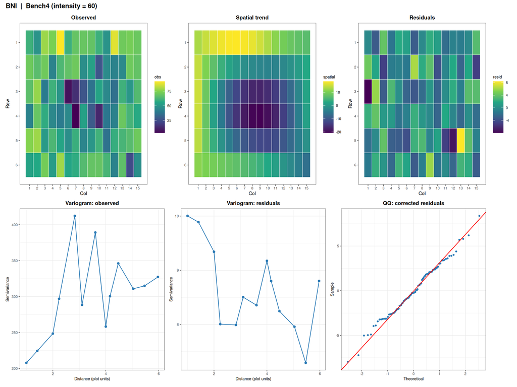

Six-panel diagnostic for Bench4 (highest spatial intensity). Top row: what the model sees. Bottom row: how well it absorbed the spatial signal.

```r
for (b in benches) {
  b_mask  <- data[[bench_col]] == b
  b_data  <- data[b_mask, ]
  b_res   <- list(
    spatial   = result$spatial[b_mask],
    residuals = result$residuals[b_mask],
    fitted    = result$fitted[b_mask]
  )

  p_diag <- make_diagnostic_plots(b_data, b_res, pheno = "BNI",
                                   row_col = row_col, col_col = col_col,
                                   bench_label = b)

  ggsave(
    file.path("figures", paste0("guide_diagnostics_BNI_", b, ".png")),
    p_diag, width = 14, height = 9, dpi = 150
  )
}

# Display Bench4 (most instructive: highest spatial intensity)
b        <- "Bench4"
b_mask   <- data[[bench_col]] == b
b_data   <- data[b_mask, ]
b_res    <- list(
  spatial   = result$spatial[b_mask],
  residuals = result$residuals[b_mask],
  fitted    = result$fitted[b_mask]
)
make_diagnostic_plots(b_data, b_res, pheno = "BNI",
                      row_col = row_col, col_col = col_col,
                      bench_label = "Bench4 (intensity = 60)")
```

## 8.1 Panel-by-panel interpretation

### 8.1.1 Panel 1: Observed heatmap (top-left)

Shows the raw measured values at each plot position, exactly as recorded. The spatial pattern is visible as structured colour gradients: if border plots are consistently darker or lighter than interior plots, there is a spatial signal.

**What to look for:** any systematic colour pattern (gradient, edge effect, striping). Random salt-and-pepper colour is measurement noise and is expected.

### 8.1.2 Panel 2: Spatial trend heatmap (top-centre)

The estimated spatial surface from the `te()` smoother, i.e. what the model attributes to the physical location rather than the genotype. This is the environmental landscape the model has learned.

**What to look for:** the surface should look like a smooth, plausible environmental gradient. If it shows the same spatial structure as the observed data (Panel 1), the model is capturing the signal. If it is flat or noisy, the spatial smoother may be under-fitted (try larger `k_row`/`k_col`).

### 8.1.3 Panel 3: Residuals heatmap (top-right)

The corrected residuals: observed values minus the full model fit (genotype effect + spatial surface + random effects). These represent what remains unexplained.

**What to look for:** the residuals should show **no systematic spatial structure**; they should look like random noise. If you can still see a gradient or edge effect in the residuals, the spatial correction was incomplete (the smoother may not have had enough flexibility). Compare the colour scale range in Panel 3 to Panel 1: a large reduction indicates effective correction.

### 8.1.4 Panel 4: Variogram of observed values (bottom-left)

An empirical semivariogram of the raw observed phenotype. The semivariance $\hat{\gamma}(h) = \frac{1}{2} \text{E}[(y_i - y_j)^2]$ is plotted against the distance $h$ between plot pairs.

**What to look for:** a **rising** variogram indicates spatial autocorrelation: nearby plots are more similar than distant plots. The rise should be steep when spatial gradients are strong. A flat variogram would mean no spatial structure.

### 8.1.5 Panel 5: Variogram of corrected residuals (bottom-centre)

The same semivariogram computed on the corrected residuals instead of the raw values. After successful spatial correction the variogram should be **flat** (approximately constant semivariance across all distances), indicating that the residuals are spatially uncorrelated.

**What to look for:** the sill (plateau level) should be much lower than in Panel 4, and the variogram should be approximately flat from small distances onwards. A rising corrected variogram means spatial autocorrelation remains in the residuals, so the correction was insufficient.

### 8.1.6 Panel 6: QQ plot of corrected residuals (bottom-right)

A quantile-quantile plot comparing the distribution of corrected residuals to a theoretical normal distribution. Points falling on the diagonal line are consistent with normality.

**What to look for:** the central range of the residuals should track the diagonal closely. Systematic deviations at the tails (heavy tails or asymmetry) may indicate outliers, non-normality of the error distribution, or genotypes with an unusually large true effect that the model is struggling with.

# 9 Step 7: Check all four benches

Compare the diagnostic plots across benches to see how increasing spatial intensity affects the correction.

```r
data$spatial_est <- result$spatial

p_sp_est <- plot_all_bench_heatmaps(
  dfr          = data,
  pheno        = "spatial_est",
  bench_col    = "Bench",
  shared_scale = TRUE,
  output_png   = "figures/guide_estimated_spatial.png",
  ncol_panels  = 2
) + plot_annotation(
  title    = "Estimated spatial trends (joint model)",
  subtitle = "Shared colour scale. Compare to true spatial patterns above.",
  theme    = theme(plot.title    = element_text(size = 13, face = "bold"),
                   plot.subtitle = element_text(size = 9, colour = "grey40"))
)
```

```
## Heatmap saved to: figures/guide_estimated_spatial.png
```

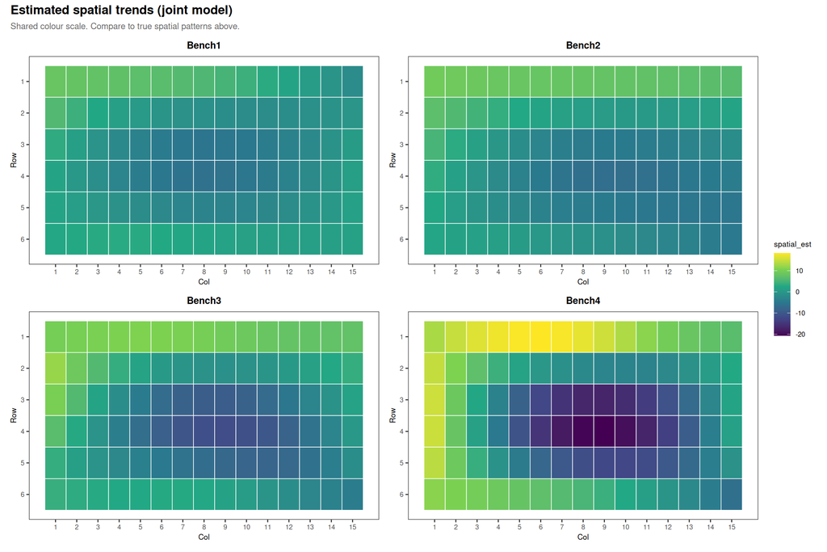

Estimated spatial trend surfaces for all four benches on a shared colour scale. The model captures both the edge-effect structure and the increasing intensity from Bench1 to Bench4.

```r
p_sp_est
```

# 10 Step 8: Validate the correction

Because this is simulated data, we can compare the recovered BLUEs directly to the true genotype effects to quantify how well the correction worked.

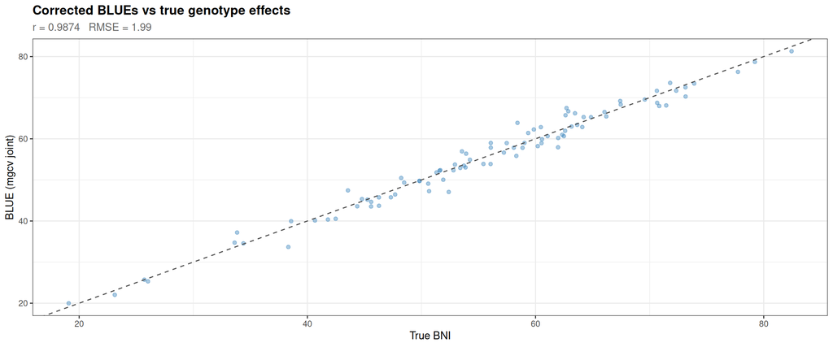

Spatially corrected BLUEs (joint mgcv model) versus true genotype effects. Compare to the uncorrected means plot above: the cloud is tighter around the 1:1 line, RMSE is smaller, and correlation is higher.

```r
merged <- merge(blues_df[, c(geno_col, "BNI")], true_effects, by = "Genotype")

r_blue    <- round(cor(merged$BNI, merged$True_BNI), 4)
rmse_blue <- round(sqrt(mean((merged$BNI - merged$True_BNI)^2)), 2)

ggplot(merged, aes(x = True_BNI, y = BNI)) +
  geom_point(alpha = 0.4, size = 1.5, colour = "#2c7bb6") +
  geom_abline(slope = 1, intercept = 0, colour = "grey30",
              linetype = "dashed", linewidth = 0.5) +
  labs(
    title    = "Corrected BLUEs vs true genotype effects",
    subtitle = paste0("r = ", r_blue, "   RMSE = ", rmse_blue),
    x        = "True BNI",
    y        = "BLUE (mgcv joint)"
  ) +
  theme_bw(base_size = 11) +
  theme(plot.title    = element_text(face = "bold"),
        plot.subtitle = element_text(colour = "grey40"))
```

```r
cat("---------------------------------------------\n")
cat(sprintf("  %-25s  r = %.4f   RMSE = %.2f\n",
            "Uncorrected means:", r_unc, rmse_unc))
```

```
##   Uncorrected means:         r = 0.9430   RMSE = 4.32
```

```r
cat(sprintf("  %-25s  r = %.4f   RMSE = %.2f\n",
            "Joint mgcv BLUEs:", r_blue, rmse_blue))
```

```
##   Joint mgcv BLUEs:          r = 0.9874   RMSE = 1.99
```

```r
cat("---------------------------------------------\n")
```

The reduction in RMSE and increase in correlation demonstrate that the spatial correction successfully recovered genotype effects that are much closer to the truth than the raw means.

# 11 Step 9: Extras – BLUE distribution and spatial surfaces

`run_spatial_gam()` also saves two summary plots automatically.

## 11.1 BLUE distribution

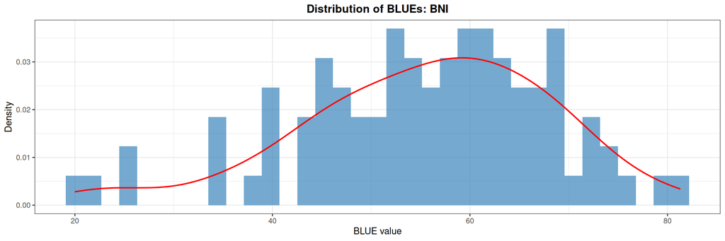

Distribution of BLUEs. A roughly normal shape centred on the grand mean is expected when genotype effects are drawn from a normal distribution. Unusual spikes or heavy tails may indicate a few genotypes with very extreme values.

```r
ggplot(blues_df, aes(x = BNI)) +
  geom_histogram(aes(y = after_stat(density)),
                 bins = 35, fill = "#2c7bb6", alpha = 0.65) +
  geom_density(colour = "red", linewidth = 0.8) +
  labs(title = "Distribution of BLUEs: BNI",
       x = "BLUE value", y = "Density") +
  theme_bw(base_size = 11) +
  theme(plot.title = element_text(face = "bold", hjust = 0.5))
```

## 11.2 Spatial surfaces (shared scale)

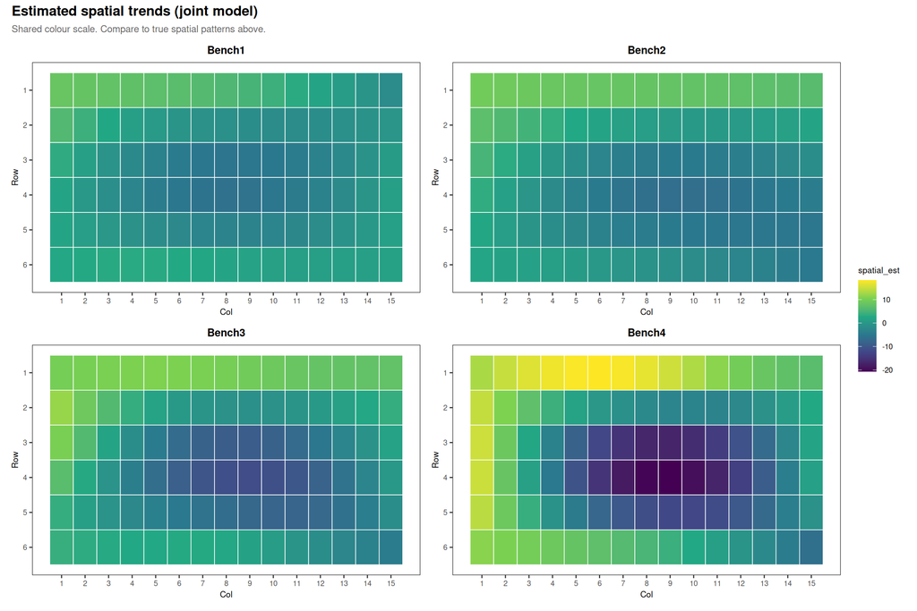

Estimated spatial trend surfaces for all four benches. These are saved to spatial_surfaces.png in the output directory by run_spatial_gam().

```r
p_sp_est
```

# 12 Using `run_spatial_gam()` in practice

For routine use, source the script and call the function with your data:

```r
source("scripts/spatial_correct_gam.R")

out <- run_spatial_gam(
  data_file     = "data/mydata.csv",
  pheno_cols    = c("yield", "height"),
  output_dir    = "output/gam",
  geno_col      = "Genotype",
  row_col       = "Row",
  col_col       = "Col",
  bench_col     = "Bench",       # omit or set NULL for single-bench
  estimate_type = "BLUEs"
)

# Access results directly
head(out$blues)
head(out$spatial_trends)
print(out$model_summary)
```

All outputs are also written to `output_dir`:

| File | Description |
| --- | --- |
| `BLUEs.csv` | One row per genotype; one value + SE column per trait |
| `BLUPs.csv` | Same structure, for BLUPs (only if `estimate_type = "BLUPs"` or `"both"`) |
| `spatial_trends.csv` | Per-plot estimated spatial effect for quality control |
| `model_summary.csv` | Residual SD, spatial EDF, convergence status per trait |
| `diagnostics_{trait}_{bench}.png` | 6-panel diagnostic per bench per trait |
| `blues_distribution.png` | Histogram and density of BLUEs per trait |
| `spatial_surfaces.png` | Spatial trend panels for all benches |

# 13 Function reference

## 13.1 `run_spatial_gam(...)`

End-to-end spatial correction pipeline. Reads data, validates columns, fits the model, writes all outputs, and returns results invisibly.

| Argument | Default | Description |
| --- | --- | --- |
| `data_file` | (required) | Path to input file (`.csv`, `.rda`, or `.RData`) |
| `pheno_cols` | (required) | Character vector of phenotype column names |
| `output_dir` | `"output/gam"` | Output directory; created automatically if absent |
| `geno_col` | `"geno"` | Genotype identifier column name |
| `row_col` | `"row"` | Row coordinate column name (must be numeric) |
| `col_col` | `"col"` | Column coordinate column name (must be numeric) |
| `bench_col` | `NULL` | Bench column name; `NULL` triggers the single-bench model |
| `estimate_type` | `"BLUEs"` | One of `"BLUEs"`, `"BLUPs"`, or `"both"` |
| `k_row` | `NULL` | Basis dimension for rows; `NULL` = auto via `adaptive_nseg()` |
| `k_col` | `NULL` | Basis dimension for columns; `NULL` = auto |
| `rda_object` | `NULL` | Object name to extract from `.rda` file; `NULL` = first data frame |

**Returns:** named list (invisible): `$blues`, `$blups`, `$spatial_trends`, `$model_summary`. All elements are data frames or `NULL` if not computed.

## 13.2 `adaptive_nseg(n_unique)`

Chooses the number of B-spline basis functions for the spatial smoother automatically from the number of unique positions along one axis.

Rule: `min(max(5, floor(n_unique / 2)), 20)`, i.e. roughly half the unique positions, bounded between 5 and 20. This prevents over-fitting in small grids and under-fitting in large ones.

| Argument | Type | Description |
| --- | --- | --- |
| `n_unique` | integer | Number of unique positions along one coordinate axis |

**Returns:** integer.

## 13.3 `read_input(fn, rda_object = NULL)`

Reads a field trial data file into a data frame.

Supports CSV (`.csv`) and R binary files (`.rda`, `.RData`). For R binary files, the first data frame in the file is returned unless `rda_object` specifies the object name.

| Argument | Default | Description |
| --- | --- | --- |
| `fn` | (required) | Path to the data file |
| `rda_object` | `NULL` | Name of the object to extract from a `.rda` file; `NULL` = use the first data frame found |

**Returns:** data.frame. Stops with an informative message if the file is not found or the extension is not recognised.

## 13.4 `empirical_semivariogram(data, row_col, col_col, value_col, n_bins = 15)`

| Argument | Default | Description |
| --- | --- | --- |
| `data` | (required) | data.frame containing the coordinates and value columns |
| `row_col` | (required) | Name of the row coordinate column |
| `col_col` | (required) | Name of the column coordinate column |
| `value_col` | (required) | Name of the value column |
| `n_bins` | `15` | Number of distance lag bins |

**Returns:** data.frame with columns `dist` (mean distance in each bin) and `sv` (mean semivariance), sorted by `dist`. Returns `NULL` when fewer than 10 non-missing observations are available.

## 13.5 `plot_heatmap(data, row_col, col_col, value_col, title = "", limits = NULL)`

Plots a field layout as a colour tile grid using `ggplot2`. Row 1 is placed at the top (y-axis reversed to match field convention); column 1 is at the left.

| Argument | Default | Description |
| --- | --- | --- |
| `data` | (required) | data.frame with coordinates and fill column |
| `row_col` | (required) | Name of the row coordinate column |
| `col_col` | (required) | Name of the column coordinate column |
| `value_col` | (required) | Name of the fill column |
| `title` | `""` | Plot title |
| `limits` | `NULL` | `c(min, max)` for the viridis fill scale; `NULL` = auto from data |

**Returns:** ggplot object. Compose multiple plots with `patchwork::wrap_plots()`.

## 13.6 `plot_variogram(vgram, title = "")`

Plots an empirical semivariogram returned by `empirical_semivariogram()`. Returns a blank placeholder panel labelled “Insufficient data” when `vgram` is `NULL` or empty, so it is safe to use even when data are sparse.

| Argument | Default | Description |
| --- | --- | --- |
| `vgram` | (required) | data.frame with columns `dist` and `sv`, as returned by `empirical_semivariogram()` |
| `title` | `""` | Plot title |

**Returns:** ggplot object.

## 13.7 `make_diagnostic_plots(bench_data, result, pheno, row_col, col_col, bench_label = "")`

Composes the 6-panel diagnostic figure for one bench x trait combination. Panels (left to right, top to bottom):

1. **Observed**: raw phenotype heatmap
2. **Spatial trend**: estimated spatial surface from the `te()` smoother
3. **Residuals**: corrected residuals heatmap
4. **Variogram: observed**: semivariogram of the raw phenotype
5. **Variogram: residuals**: semivariogram of the corrected residuals
6. **QQ plot**: quantile-quantile plot of corrected residuals vs. normal

| Argument | Default | Description |
| --- | --- | --- |
| `bench_data` | (required) | data.frame for the bench, containing the observed phenotype column |
| `result` | (required) | Named list with elements `$spatial`, `$residuals`, `$fitted`, as returned by `fit_mgcv_bench()` or `fit_mgcv_joint()` |
| `pheno` | (required) | Name of the phenotype column in `bench_data` |
| `row_col` | (required) | Name of the row coordinate column |
| `col_col` | (required) | Name of the column coordinate column |
| `bench_label` | `""` | Label shown in the figure title |

**Returns:** patchwork ggplot (2 x 3 grid). Save with `ggsave()`.

## 13.8 `fit_mgcv_bench(bench_data, pheno, geno_col, row_col, col_col, k_row = NULL, k_col = NULL, estimate_type = "BLUEs")`

Fits the `te_ps_re` spatial correction model for a **single bench**.

The GAM formula for BLUEs is:

```
pheno ~ 0 + Genotype + te(Row, Col, bs=c('ps','ps'), k=c(kr,kc)) +
        s(row_f, bs='re') + s(col_f, bs='re')
```

| Argument | Default | Description |
| --- | --- | --- |
| `bench_data` | (required) | data.frame for one bench |
| `pheno` | (required) | Name of the phenotype column |
| `geno_col` | (required) | Name of the genotype column |
| `row_col` | (required) | Name of the row coordinate column |
| `col_col` | (required) | Name of the column coordinate column |
| `k_row` | `NULL` | Basis dimension for rows; `NULL` = determined by `adaptive_nseg()` |
| `k_col` | `NULL` | Basis dimension for columns; `NULL` = determined by `adaptive_nseg()` |
| `estimate_type` | `"BLUEs"` | `"BLUEs"`, `"BLUPs"`, or `"both"` |

**Returns:** named list:

| Element | Description |
| --- | --- |
| `$blues` | data.frame(`Genotype`, `BLUE`, `BLUE_SE`); `NULL` if not requested |
| `$blups` | data.frame(`Genotype`, `BLUP`, `BLUP_SE`); `NULL` if not requested |
| `$fitted` | Numeric vector of model fitted values (length = nrow(bench_data)) |
| `$residuals` | Numeric vector of model residuals |
| `$spatial` | Numeric vector of estimated spatial contribution at each plot |
| `$converged` | Logical; whether REML optimisation converged |
| `$edf_spatial` | Numeric; sum of EDF of all `te()` smooth terms |

## 13.9 `fit_mgcv_joint(data, pheno, geno_col, row_col, col_col, bench_col, k_row = NULL, k_col = NULL, estimate_type = "BLUEs")`

Fits the `te_ps_re` spatial correction model **jointly across all benches**.

The GAM formula is:

```
pheno ~ 0 + Genotype + bench_f +
        te(Row, Col, bs=c('ps','ps'), k=c(kr,kc), by=bench_f) +
        s(row_f, bench_f, bs='re') +
        s(col_f, bench_f, bs='re')
```

The `by = bench_f` term creates an independent spatial surface for each bench within the single joint model. The basis dimension `k` is chosen from the minimum bench grid dimension across all benches, ensuring a valid model even when benches differ in size.

| Argument | Default | Description |
| --- | --- | --- |
| `data` | (required) | Full data.frame (all benches combined) |
| `pheno` | (required) | Name of the phenotype column |
| `geno_col` | (required) | Name of the genotype column |
| `row_col` | (required) | Name of the row coordinate column |
| `col_col` | (required) | Name of the column coordinate column |
| `bench_col` | (required) | Name of the bench identifier column |
| `k_row` | `NULL` | Basis dimension for rows; `NULL` = auto |
| `k_col` | `NULL` | Basis dimension for columns; `NULL` = auto |
| `estimate_type` | `"BLUEs"` | Only `"BLUEs"` is supported for the joint model |

**Returns:** named list with the same structure as `fit_mgcv_bench()`, except `$blues` is always populated (joint model only supports BLUEs) and `$spatial` is the concatenated spatial trend across all benches in the same row order as the input `data`.